# Fruit360_all

In this kernel I will use different machine learning models, including Random Forest, Logistic Regression, Extra Trees, K Nearest Neighbors, Fully Connected Neural Network and Convolutional Neural Network, to classify 69 classes of fruit from images. Transfer learning will also be used based on VGG16 model fitted to ImageNet dataset. The datasets are downloaded from Kaggle dataset. The training dataset includes 34641 images and the testing dataset includes 11640 images.

```python
import numpy as np
import matplotlib.pyplot as plt
import keras
import tensorflow as tf
import os
import glob
import platform
import cv2
from sklearn import svm
from sklearn.externals import joblib
from sklearn.ensemble import RandomForestClassifier, ExtraTreesClassifier
from sklearn.linear_model import LogisticRegression
from sklearn.neighbors import KNeighborsClassifier
from keras.models import Sequential, Model
from keras.layers import Dense, Dropout, Flatten, Conv2D, MaxPool2D, BatchNormalization
from keras.layers import LSTM, Input
from keras.optimizers import RMSprop, Adamax
```

## Reading the data

```python
# Reading all pictures
# Each picture -> array of height x width x 3 dimenion
img_height = 48
img_width = 48
train_fruit_images = []
train_labels = []
# Loop over folder inside Training
whatos = platform.system()
for fruit_dir_path in glob.glob("Training/*"):
    if whatos == 'Windows':
        fruit_label = fruit_dir_path.split("\\")[-1]
    else: # Linux and Mac (Unix)
        fruit_label = fruit_dir_path.split("/")[-1]
    # Loop over each pic in each folder inside Training
    for image_path in glob.glob(os.path.join(fruit_dir_path, "*.jpg")):
        image = cv2.imread(image_path, cv2.IMREAD_COLOR)

        image = cv2.resize(image, (img_height, img_width))
        image = cv2.cvtColor(image, cv2.COLOR_RGB2BGR)

        train_fruit_images.append(image)
        train_labels.append(fruit_label)
train_fruit_images = np.array(train_fruit_images)
train_labels = np.array(train_labels)
```

```python
label_to_id_dict = {v:i for i,v in enumerate(np.unique(train_labels))}
id_to_label_dict = {v: k for k, v in label_to_id_dict.items()}
train_label_ids = np.array([label_to_id_dict[label] for label in train_labels])
```

```python
# Same for test set, reading all pictures
# Each picture -> array of height x width x 3 dimenion
test_fruit_images = []
test_labels = []
# Loop over folder inside Validation
whatos = platform.system()
for fruit_dir_path in glob.glob("Validation/*"):
    if whatos == 'Windows':
        fruit_label = fruit_dir_path.split("\\")[-1]
    else: # Linux and Mac (Unix)
        fruit_label = fruit_dir_path.split("/")[-1]
    # Loop over each pic in each folder inside Validation
    for image_path in glob.glob(os.path.join(fruit_dir_path, "*.jpg")):
        image = cv2.imread(image_path, cv2.IMREAD_COLOR)

        image = cv2.resize(image, (img_height, img_width))
        image = cv2.cvtColor(image, cv2.COLOR_RGB2BGR)

        test_fruit_images.append(image)
        test_labels.append(fruit_label)
test_fruit_images = np.array(test_fruit_images)
test_labels = np.array(test_labels)
```

```python
test_label_ids = np.array([label_to_id_dict[label] for label in test_labels])
```

## Plotting some tranining samples

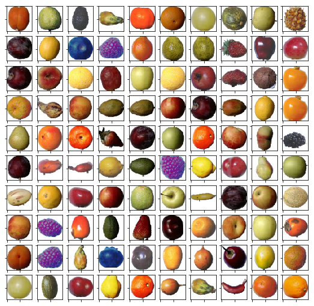

```python
# Plotting some training samples
nplot=10
fig, axes = plt.subplots(nplot, nplot, sharex=True, sharey=True, figsize=(9,9))
train_index = np.arange(0,train_fruit_images.shape[0])
for i in range(nplot):
    for j in range(nplot):
        axes[i,j].imshow(train_fruit_images[np.random.choice(train_index,1,replace=False)[0]])
        axes[i,j].set_xticklabels([])
        axes[i,j].set_yticklabels([])
        #axes[i,j].axis('off')
plt.show()
```

[figure not shown]

```python
# Examples of training samples for one fruit
nplot = 10
offset = 492*5
fig, axes = plt.subplots(nplot, nplot, sharex=True, sharey=True, figsize=(9,9))
for i in range(nplot):
    for j in range(nplot):
        axes[i,j].imshow(train_fruit_images[i*nplot+j+offset])
        axes[i,j].set_xticklabels([])
        axes[i,j].set_yticklabels([])
        #axes[i,j].axis('off')
plt.show()
```

## Train-Test sets

```python
# Train-Test
X_train = train_fruit_images
Y_train = train_label_ids
X_test = test_fruit_images
Y_test = test_label_ids

# Normalizing features between 0 and 1
X_train = X_train/255
X_test = X_test/255

# Flattening each image features to 1D-array
X_train_flat = X_train.reshape(X_train.shape[0], img_height*img_width*3)
X_test_flat = X_test.reshape(X_test.shape[0], img_height*img_width*3)

# One-hot encode of the Output
Y_train = keras.utils.to_categorical(Y_train, len(label_to_id_dict))
Y_test = keras.utils.to_categorical(Y_test, len(label_to_id_dict))

# Shape of input and output
print('Original Sizes:', X_train.shape, X_test.shape, Y_train.shape, Y_test.shape)
print('Flattened:', X_train_flat.shape, X_test_flat.shape)
```

```
Original Sizes: (34641, 48, 48, 3) (11640, 48, 48, 3) (34641, 69) (11640, 69)
Flattened: (34641, 6912) (11640, 6912)
```

# Prediction Models

## Random Forest

```python
error_nestimators = []
for n_estimators in [10, 20, 30, 40, 50, 60, 70, 80]:
    #print('Number of Trees: ', n_estimators)
    rf_clf = RandomForestClassifier(n_estimators=n_estimators, oob_score=True)
    rf_clf.fit(X_train_flat, train_label_ids)
    fit_score = rf_clf.score(X_train_flat, train_label_ids)
    test_score = rf_clf.score(X_test_flat, test_label_ids)
    #print('Fitting score: ', fit_score)
    #print('Testng score: ', test_score)
    error_nestimators.append([n_estimators, fit_score, test_score, rf_clf.oob_score_])
error_nestimators = np.array(error_nestimators)
```

```python
error_maxfeatures = []
for max_features in ['sqrt','log2', None]:
    #print('Number of Trees: ', max_features)
    rf_clf = RandomForestClassifier(n_estimators=30, max_features=max_features)
    rf_clf.fit(X_train_flat, train_label_ids)
    fit_score = rf_clf.score(X_train_flat, train_label_ids)
    test_score = rf_clf.score(X_test_flat, test_label_ids)
    #print('Fitting score: ', fit_score)
    #print('Testng score: ', test_score)
    error_maxfeatures.append([max_features, fit_score, test_score])
error_maxfeatures = np.array(error_maxfeatures)
```

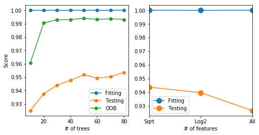

```python
fig, (ax1, ax2) = plt.subplots(1,2, figsize=(8,4))
ax1.plot(error_nestimators[:,0], error_nestimators[:,1], marker='o', label='Fitting')
ax1.plot(error_nestimators[:,0], error_nestimators[:,2], marker='o', label='Testing')
ax1.plot(error_nestimators[:,0], error_nestimators[:,3], marker='o', label='OOB')
ax1.set_xlabel('# of trees')
ax1.set_ylabel('Score')
ax1.legend()

ax2.plot([0,1,2], error_maxfeatures[:,1], marker='o', markersize=10, label='Fitting')
ax2.plot([0,1,2], error_maxfeatures[:,2], marker='o', markersize=10, label='Testing')
ax2.set_xlabel('# of features')
#ax2.set_ylabel('Score')
ax2.set_xlim(0,2)
ax2.set_xticks([0,1,2])
ax2.set_xticklabels(['Sqrt','Log2','All'])
ax2.legend()

plt.show()
```

## Extra Tree or Extremely Randominzed Trees

```python
error_nestimators = []
for n_estimators in [10, 20, 30, 40, 50, 60, 70, 80]:
    #print('Number of Trees: ', n_estimators)
    et_clf = ExtraTreesClassifier(n_estimators=n_estimators)
    et_clf.fit(X_train_flat, train_label_ids)
    fit_score = et_clf.score(X_train_flat, train_label_ids)
    test_score = et_clf.score(X_test_flat, test_label_ids)
    error_nestimators.append([n_estimators, fit_score, test_score])
error_nestimators = np.array(error_nestimators)
```

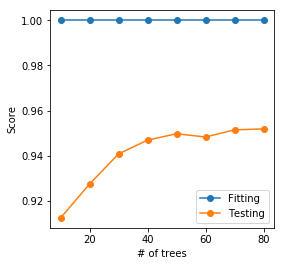

```python
fig, ax1 = plt.subplots(1,1, figsize=(4,4))
ax1.plot(error_nestimators[:,0], error_nestimators[:,1], marker='o', label='Fitting')
ax1.plot(error_nestimators[:,0], error_nestimators[:,2], marker='o', label='Testing')
ax1.set_xlabel('# of trees')
ax1.set_ylabel('Score')
ax1.legend()
plt.show()
```

The best result is for 80 trees and the fitting score is 1.0 and testing score is 0.952, very slightly less than Random Forest Classifier. This is reasonable since Random Forest and Extra Tree methods are very similar. However, both models are quite overfit.

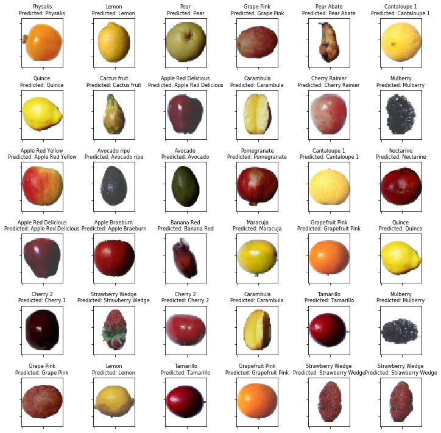

```python
nplotx=6
nploty=6
model = rf_clf
fig, axes = plt.subplots(nploty, nplotx, sharex=True, sharey=True, figsize=(10,10))
test_index = np.arange(0,test_fruit_images.shape[0])
for i in range(nploty):
    for j in range(nplotx):
        ind=np.random.choice(test_index,1,replace=False)[0]
        axes[i,j].imshow(test_fruit_images[ind])
        axes[i,j].set_xticklabels([])
        axes[i,j].set_yticklabels([])
        axes[i,j].set_title(str(test_labels[ind])+'\n'+'Predicted: '+str(id_to_label_dict[model.predict(X_test_flat[ind:ind+1])[0]]), fontsize=8)
plt.tight_layout()
plt.show()
```

## Logistic Regression

```python
lg_error = []
for C in [10000, 100, 1.0, 0.01, 0.0001]:
    lg_clf = LogisticRegression(C=C)
    lg_clf.fit(X_train_flat, train_label_ids)
    fit_score = lg_clf.score(X_train_flat, train_label_ids)
    test_score = lg_clf.score(X_test_flat, test_label_ids)
    lg_error.append([C, fit_score, test_score])
lg_error = np.array(lg_error)
```

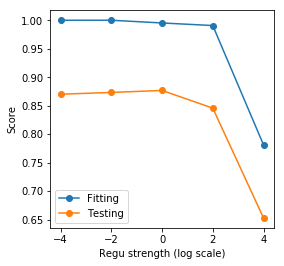

```python
fig, ax1 = plt.subplots(1,1, figsize=(4,4))
ax1.plot(np.log10(1/lg_error[:,0]), lg_error[:,1], marker='o', label='Fitting')
ax1.plot(np.log10(1/lg_error[:,0]), lg_error[:,2], marker='o', label='Testing')
ax1.set_xlabel('Regu strength (log scale)')
ax1.set_ylabel('Score')
ax1.legend()
plt.show()
```

For C = 1 we can get fitting score 1.0 and testing score 0.878, which are quite overfitted. However, increasing regularization strength, we can not reduce overfit a significantly. For very large regularization strength, both fitting and testing score reduce significantly, about 0.78 for fitting and 0.66 for testing.

```python
C=1
lg_clf = LogisticRegression(C=C)
lg_clf.fit(X_train_flat, train_label_ids)
nplotx=6
nploty=6
model = lg_clf
fig, axes = plt.subplots(nploty, nplotx, sharex=True, sharey=True, figsize=(10,10))
test_index = np.arange(0,test_fruit_images.shape[0])
for i in range(nploty):
    for j in range(nplotx):
        ind=np.random.choice(test_index,1,replace=False)[0]
        axes[i,j].imshow(test_fruit_images[ind])
        axes[i,j].set_xticklabels([])
        axes[i,j].set_yticklabels([])
        axes[i,j].set_title(str(test_labels[ind])+'\n'+'Predicted: '+str(id_to_label_dict[model.predict(X_test_flat[ind:ind+1])[0]]), fontsize=8)
plt.tight_layout()
plt.show()
```

[output not shown]

## KNN

```python
knn_error = []
for kn in [3, 5, 10, 20]:
    knn_clf = KNeighborsClassifier(n_neighbors=kn)
    knn_clf.fit(X_train_flat, train_label_ids)
    fit_score = knn_clf.score(X_train_flat, train_label_ids)
    test_score = knn_clf.score(X_test_flat, test_label_ids)
    knn_error.append([kn, fit_score, test_score])
knn_error = np.array(knn_error)
```

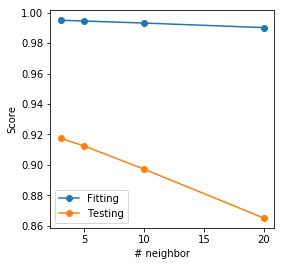

```python
fig, ax1 = plt.subplots(1,1, figsize=(4,4))
ax1.plot(knn_error[:,0], knn_error[:,1], marker='o', label='Fitting')
ax1.plot(knn_error[:,0], knn_error[:,2], marker='o', label='Testing')
ax1.set_xlabel('# neighbor')
ax1.set_ylabel('Score')
ax1.legend()
plt.show()
```

We can get a testing score of ~ 0.919 with k3. Increasing number of neighbors, both fitting and testing scores are decreasing but we can not reduce overfit. As above model, KNN is also quite overfitted to the current fruit classification problem.

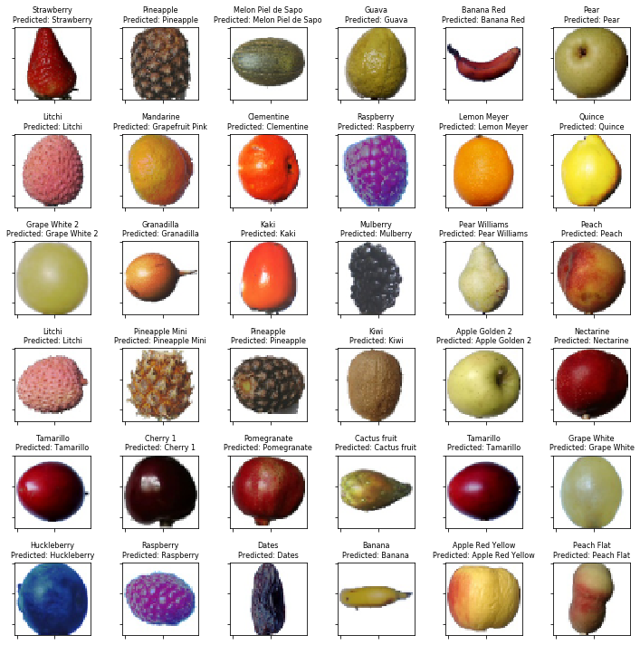

```python
kn = 3
knn_clf = KNeighborsClassifier(n_neighbors=kn)
knn_clf.fit(X_train_flat, train_label_ids)
nplotx=6
nploty=6
model = knn_clf
fig, axes = plt.subplots(nploty, nplotx, sharex=True, sharey=True, figsize=(10,10))
test_index = np.arange(0,test_fruit_images.shape[0])
for i in range(nploty):
    for j in range(nplotx):
        ind=np.random.choice(test_index,1,replace=False)[0]
        axes[i,j].imshow(test_fruit_images[ind])
        axes[i,j].set_xticklabels([])
        axes[i,j].set_yticklabels([])
        axes[i,j].set_title(str(test_labels[ind])+'\n'+'Predicted: '+str(id_to_label_dict[model.predict(X_test_flat[ind:ind+1])[0]]), fontsize=8)
plt.tight_layout()
plt.show()
```

## Neural Networks

First we will use fully connected neural networks model with Keras package with TensorFlow as backend.

```python
#1st very simple model
model_dense = Sequential()
model_dense.add(Dense(256, activation='relu', input_shape=(X_train_flat.shape[1],)))
# Dropout layer to reduce variance
model_dense.add(Dropout(0.1))
model_dense.add(Dense(64, activation='relu'))
model_dense.add(Dropout(0.1))
model_dense.add(Dense(Y_train.shape[1], activation='softmax'))

# Summary of model
model_dense.summary()

# Compiling model
model_dense.compile(loss='categorical_crossentropy', optimizer=RMSprop(), metrics=['accuracy'])

history_model_dense = model_dense.fit(X_train_flat, Y_train, batch_size=128, epochs=30, validation_data=(X_test_flat, Y_test))
score = model_dense.evaluate(X_test_flat, Y_test, verbose=0)
print('Test loss: ', score[0])
print('Test accuracy: ', score[1])
```

```
_________________________________________________________________
Layer (type)                 Output Shape              Param #
=================================================================
dense_1 (Dense)              (None, 256)               1769728
_________________________________________________________________
dropout_1 (Dropout)          (None, 256)               0
_________________________________________________________________
dense_2 (Dense)              (None, 64)                16448
_________________________________________________________________
dropout_2 (Dropout)          (None, 64)                0
_________________________________________________________________
dense_3 (Dense)              (None, 69)                4485
=================================================================
Total params: 1,790,661
Trainable params: 1,790,661
Non-trainable params: 0
_________________________________________________________________
Train on 34641 samples, validate on 11640 samples
Test loss:  0.51076778593
Test accuracy:  0.869501718213
```

```python
# Deeper model
model_dense = Sequential()
model_dense.add(Dense(256, activation='relu', input_shape=(X_train_flat.shape[1],)))
# Dropout layer to reduce variance
model_dense.add(Dropout(0.2))
model_dense.add(Dense(128, activation='relu'))
# Batch Normalization to stabilize fitting and partially to reduce variance
model_dense.add(BatchNormalization())
model_dense.add(Dense(128, activation='relu'))
model_dense.add(BatchNormalization())
model_dense.add(Dense(128, activation='relu'))
model_dense.add(Dropout(0.5))
model_dense.add(Dense(Y_train.shape[1], activation='softmax'))

# Summary of model
model_dense.summary()

# Compiling model
model_dense.compile(loss='categorical_crossentropy', optimizer=RMSprop(), metrics=['accuracy'])

history_model_dense = model_dense.fit(X_train_flat, Y_train, batch_size=128, epochs=30, validation_data=(X_test_flat, Y_test))
score = model_dense.evaluate(X_test_flat, Y_test, verbose=0)
print('Test loss: ', score[0])
print('Test accuracy: ', score[1])
```

```
_________________________________________________________________
Layer (type)                 Output Shape              Param #
=================================================================
dense_9 (Dense)              (None, 256)               1769728
_________________________________________________________________
dropout_6 (Dropout)          (None, 256)               0
_________________________________________________________________
dense_10 (Dense)             (None, 128)               32896
_________________________________________________________________
batch_normalization_2 (Batch (None, 128)               512
_________________________________________________________________
dense_11 (Dense)             (None, 128)               16512
_________________________________________________________________
batch_normalization_3 (Batch (None, 128)               512
_________________________________________________________________
dense_12 (Dense)             (None, 128)               16512
_________________________________________________________________
dropout_7 (Dropout)          (None, 128)               0
_________________________________________________________________
dense_13 (Dense)             (None, 69)                8901
=================================================================
Total params: 1,845,573
Trainable params: 1,845,061
Non-trainable params: 512
_________________________________________________________________
Train on 34641 samples, validate on 11640 samples
Test loss:  0.272828678756
Test accuracy:  0.93616838488
```

It's great! With a bit deeper networks, we can archive 0.934 for testing and 0.962 for fitting. There is still overfitting here live above model, but it is less. Dropout was already used to avoid overfit but we still can not avoid it completely. We can use early stop to futher avoid overfit. For example of our case here, we can stop after 7 epochs to have a very a very well generalized neural network model with both fitting and testing score about 0.92! We can expect to get better model with convolutional neural networks (CNN). Let try out CNN!

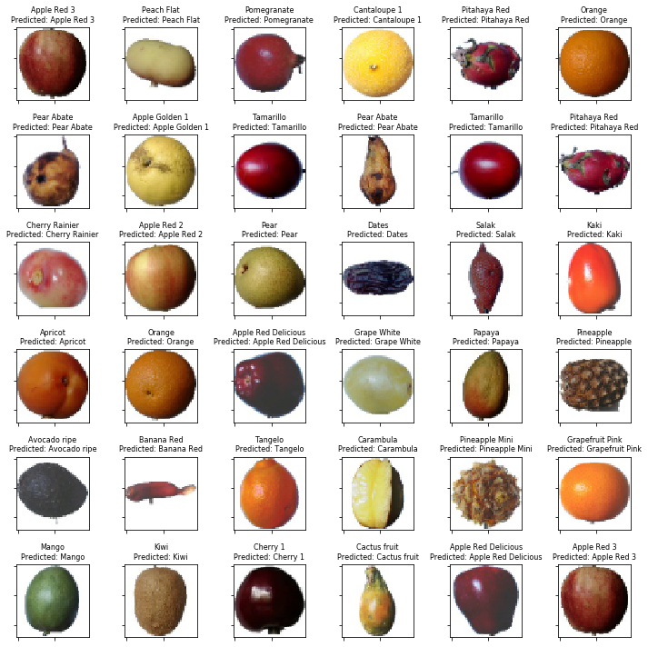

```python
nplotx=6
nploty=6
model = model_dense
fig, axes = plt.subplots(nploty, nplotx, sharex=True, sharey=True, figsize=(10,10))
test_index = np.arange(0,test_fruit_images.shape[0])
for i in range(nploty):
    for j in range(nplotx):
        ind=np.random.choice(test_index,1,replace=False)[0]
        axes[i,j].imshow(test_fruit_images[ind])
        axes[i,j].set_xticklabels([])
        axes[i,j].set_yticklabels([])
        axes[i,j].set_title(str(test_labels[ind])+'\n'+'Predicted: '+str(id_to_label_dict[model.predict(X_test_flat[ind:ind+1]).argmax()]), fontsize=8)
plt.tight_layout()
plt.show()
```

```python
# CNN
# Stacking model
model_cnn = Sequential()
model_cnn.add(Conv2D(filters=32, kernel_size=(3,3), activation='relu', input_shape=(img_height, img_width, 3)))
model_cnn.add(Conv2D(filters=64, kernel_size=(3,3), activation='relu'))
model_cnn.add(MaxPool2D(pool_size=(2,2)))
#model_cnn.add(BatchNormalization())
model_cnn.add(Dropout(0.25))
model_cnn.add(Flatten())
model_cnn.add(Dense(128, activation='relu'))
model_cnn.add(Dropout(0.25))
model_cnn.add(Dense(Y_train.shape[1], activation='softmax'))

# Compiling model
model_cnn.compile(loss='categorical_crossentropy',
                  optimizer=Adamax(),
                  metrics=['accuracy']
                 )
model_cnn.summary()
```

```
_________________________________________________________________
Layer (type)                 Output Shape              Param #
=================================================================
conv2d_1 (Conv2D)            (None, 46, 46, 32)        896
_________________________________________________________________
conv2d_2 (Conv2D)            (None, 44, 44, 64)        18496
_________________________________________________________________
max_pooling2d_1 (MaxPooling2 (None, 22, 22, 64)        0
_________________________________________________________________
dropout_8 (Dropout)          (None, 22, 22, 64)        0
_________________________________________________________________
flatten_1 (Flatten)          (None, 30976)             0
_________________________________________________________________
dense_14 (Dense)             (None, 128)               3965056
_________________________________________________________________
dropout_9 (Dropout)          (None, 128)               0
_________________________________________________________________
dense_15 (Dense)             (None, 69)                8901
=================================================================
Total params: 3,993,349
Trainable params: 3,993,349
Non-trainable params: 0
_________________________________________________________________
```

```python
history_model_cnn = model_cnn.fit(X_train, Y_train, batch_size=128,
             epochs=5, validation_data=(X_test, Y_test))
score = model_cnn.evaluate(X_test, Y_test)
print('Test loss: ', score[0])
print('Test accuracy: ', score[1])
```

```
Train on 34641 samples, validate on 11640 samples
Test loss:  0.163625853475
Test accuracy:  0.950429553265
```

```python
history_model_cnn = model_cnn.fit(X_train, Y_train, batch_size=128,
             epochs=5, validation_data=(X_test, Y_test))
score = model_cnn.evaluate(X_test, Y_test)
print('Test loss: ', score[0])
print('Test accuracy: ', score[1])
```

```
Train on 34641 samples, validate on 11640 samples
Test loss:  0.161873538924
Test accuracy:  0.959192439863
```

```python
# deeper CNN
# Stacking model
model_cnn2 = Sequential()
model_cnn2.add(Conv2D(filters=64, kernel_size=(3,3), activation='relu', input_shape=(img_height, img_width, 3)))
model_cnn2.add(Conv2D(filters=64, kernel_size=(3,3), activation='relu'))
model_cnn2.add(MaxPool2D(pool_size=(2,2)))
#model_cnn2.add(Dropout(0.1))
model_cnn2.add(BatchNormalization())

model_cnn2.add(Conv2D(filters=128, kernel_size=(5,5), activation='relu'))
model_cnn2.add(Conv2D(filters=128, kernel_size=(5,5), activation='relu'))
model_cnn2.add(MaxPool2D(pool_size=(2,2)))
model_cnn2.add(Flatten())
model_cnn2.add(Dropout(0.25))
model_cnn2.add(Dense(128, activation='relu'))
model_cnn2.add(Dropout(0.25))
model_cnn2.add(Dense(Y_train.shape[1], activation='softmax'))

# Compiling model
model_cnn2.compile(loss='categorical_crossentropy',
                  optimizer=Adamax(),
                  metrics=['accuracy']
                 )
model_cnn2.summary()
```

```
_________________________________________________________________
Layer (type)                 Output Shape              Param #
=================================================================
conv2d_9 (Conv2D)            (None, 46, 46, 64)        1792
_________________________________________________________________
conv2d_10 (Conv2D)           (None, 44, 44, 64)        36928
_________________________________________________________________
max_pooling2d_5 (MaxPooling2 (None, 22, 22, 64)        0
_________________________________________________________________
batch_normalization_6 (Batch (None, 22, 22, 64)        256
_________________________________________________________________
conv2d_11 (Conv2D)           (None, 18, 18, 128)       204928
_________________________________________________________________
conv2d_12 (Conv2D)           (None, 14, 14, 128)       409728
_________________________________________________________________
max_pooling2d_6 (MaxPooling2 (None, 7, 7, 128)         0
_________________________________________________________________
flatten_4 (Flatten)          (None, 6272)              0
_________________________________________________________________
dropout_13 (Dropout)         (None, 6272)              0
_________________________________________________________________
dense_20 (Dense)             (None, 128)               802944
_________________________________________________________________
dropout_14 (Dropout)         (None, 128)               0
_________________________________________________________________
dense_21 (Dense)             (None, 69)                8901
=================================================================
Total params: 1,465,477
Trainable params: 1,465,349
Non-trainable params: 128
_________________________________________________________________
```

```python
history_model_cnn2 = model_cnn2.fit(X_train, Y_train, batch_size=128,
             epochs=10, validation_data=(X_test, Y_test))
score = model_cnn2.evaluate(X_test, Y_test)
print('Test loss: ', score[0])
print('Test accuracy: ', score[1])
```

```
Train on 34641 samples, validate on 11640 samples
Test loss:  0.189316277101
Test accuracy:  0.952577319547
```

It's great! We can archive 0.952 for testing and 0.986 for fitting. There is still a bit overfitting here. We can use early stop to avoid overfit a bit more.We can stop after 7 epochs to have a very a very well generalized CNN model with fitting and testing score of 0.980 and 0.970! We can see that CNN is quite advanced than other models in image classification.

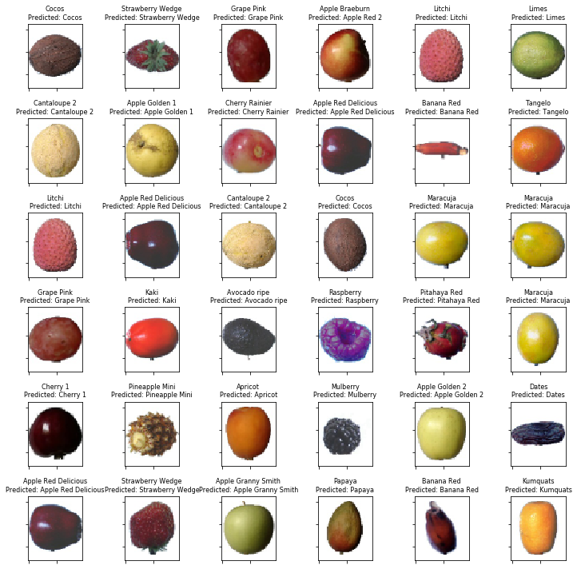

```python
nplotx=6
nploty=6
fig, axes = plt.subplots(nploty, nplotx, sharex=True, sharey=True, figsize=(10,10))
test_index = np.arange(0,test_fruit_images.shape[0])
for i in range(nploty):
    for j in range(nplotx):
        ind=np.random.choice(test_index,1,replace=False)[0]
        axes[i,j].imshow(test_fruit_images[ind])
        axes[i,j].set_xticklabels([])
        axes[i,j].set_yticklabels([])
        axes[i,j].set_title(str(test_labels[ind])+'\n'+'Predicted: '+str(id_to_label_dict[model_cnn.predict(X_test[ind:ind+1]).argmax()]), fontsize=8)
plt.tight_layout()
plt.show()
```

### Transfer learning

```python
from keras.applications.vgg16 import VGG16
from keras.applications.vgg16 import preprocess_input
```

```python
vgg_base = VGG16( include_top=False, weights='imagenet', input_shape=(img_height, img_width, 3))
# Do not change the weights
for layer in vgg_base.layers:
    layer.trainable = False
```

```python
x = Flatten()(vgg_base.output)
prediction = Dense(Y_train.shape[1], activation='softmax')(x)
vgg_model = Model(inputs=vgg_base.input, outputs=prediction)
vgg_model.summary()
vgg_model.compile(loss='categorical_crossentropy', optimizer=RMSprop(), metrics=['accuracy'])
```

```
_________________________________________________________________
Layer (type)                 Output Shape              Param #
=================================================================
input_1 (InputLayer)         (None, 48, 48, 3)         0
_________________________________________________________________
block1_conv1 (Conv2D)        (None, 48, 48, 64)        1792
_________________________________________________________________
block1_conv2 (Conv2D)        (None, 48, 48, 64)        36928
_________________________________________________________________
block1_pool (MaxPooling2D)   (None, 24, 24, 64)        0
_________________________________________________________________
block2_conv1 (Conv2D)        (None, 24, 24, 128)       73856
_________________________________________________________________
block2_conv2 (Conv2D)        (None, 24, 24, 128)       147584
_________________________________________________________________
block2_pool (MaxPooling2D)   (None, 12, 12, 128)       0
_________________________________________________________________
block3_conv1 (Conv2D)        (None, 12, 12, 256)       295168
_________________________________________________________________
block3_conv2 (Conv2D)        (None, 12, 12, 256)       590080
_________________________________________________________________
block3_conv3 (Conv2D)        (None, 12, 12, 256)       590080
_________________________________________________________________
block3_pool (MaxPooling2D)   (None, 6, 6, 256)         0
_________________________________________________________________
block4_conv1 (Conv2D)        (None, 6, 6, 512)         1180160
_________________________________________________________________
block4_conv2 (Conv2D)        (None, 6, 6, 512)         2359808
_________________________________________________________________
block4_conv3 (Conv2D)        (None, 6, 6, 512)         2359808
_________________________________________________________________
block4_pool (MaxPooling2D)   (None, 3, 3, 512)         0
_________________________________________________________________
block5_conv1 (Conv2D)        (None, 3, 3, 512)         2359808
_________________________________________________________________
block5_conv2 (Conv2D)        (None, 3, 3, 512)         2359808
_________________________________________________________________
block5_conv3 (Conv2D)        (None, 3, 3, 512)         2359808
_________________________________________________________________
block5_pool (MaxPooling2D)   (None, 1, 1, 512)         0
_________________________________________________________________
flatten_5 (Flatten)          (None, 512)               0
_________________________________________________________________
dense_22 (Dense)             (None, 69)                35397
=================================================================
Total params: 14,750,085
Trainable params: 35,397
Non-trainable params: 14,714,688
_________________________________________________________________
```

```python
history_vgg_model = vgg_model.fit(X_train, Y_train, batch_size=128, epochs=10, validation_data=(X_test, Y_test))
```

```
Train on 34641 samples, validate on 11640 samples
```